# Practical Machine Learning

Karoly Kovago

March 16, 2017

## Background

Use data from wearablefitness devices to predict a variable which describes the quality of weight lifting exercises. Build a predictive model for this “classe” variable in the training set: select a model, use cross-validation, describe the expected out of sample error. Then use the prediction model to predict 20 different test cases.

Training data:

https://d396qusza40orc.cloudfront.net/predmachlearn/pml-training.csv

Test data:

https://d396qusza40orc.cloudfront.net/predmachlearn/pml-testing.csv

## Synopsis

After cleaning the training data, applying different training methods and evaluating the prediction by cross-validation, the random forest method proved to be the most accurate. The randomforest based prediction model was used to predict 20 values for the test data. The results are displayed and written into a file called “predictionResults.txt”.

## Loading the libraries and the data

```r
# load libraries
library(caret)
library(randomForest)
library(e1071)
library(gbm)
```

```r
library(rpart)
library(plyr)

# download data if ther is no local data file yet
sourceDirURL <- "https://d396qusza40orc.cloudfront.net/predmachlearn/"
trainingFileName <- "pml-training.csv"
testFileName <- "pml-testing.csv"

downloadData <- function(sourceURL, fileName) {
    if(!file.exists(fileName))
        download.file(paste0(sourceURL, fileName),fileName)
}

# load data
downloadData(sourceDirURL, trainingFileName)
downloadData(sourceDirURL, testFileName)
```

The data, by visual inspection, contains 3 types of missing data: empty values, NA values and “#DIV/0!” values; so these converted into NA during thedata load.

```r
trainingSet <- read.csv(trainingFileName, na.strings=c("NA","#DIV/0!",""))
testSet <- read.csv(testFileName, na.strings=c("NA","#DIV/0!",""))
```

## Cleaning data

First, check columns with NA values.

```r
as.factor(apply(trainingSet, 2, function(x) sum(is.na(x)) ))[2]
```

```
## user_name
##         0
## 17 Levels: 0 19216 19217 19218 19220 19221 19225 19226 19227 ... 19622
```

Apparently all columns which have at least one NA, have NA over 90% of the records. So I will delete columns with any NA.

```r
# Find the columns with no NA
columnsNoNA <- apply(trainingSet, 2, function(x) {sum(is.na(x))==0} )
# then filter the training set to contain only those columns
trainingSet <- trainingSet[, columnsNoNA]
```

In the next step I remove zero covariates.

```r
trainingSet <- trainingSet[, nearZeroVar(trainingSet, saveMetrics=TRUE)$nzv==FALSE]
```

Finally, I find that the first 5 columns of the training data have no predictive value for ‘classe’; they are user and time stamp related data. Therefore I remove these columns.

```r
# Remove "X", "user_name", "raw_timestamp_part_1", "raw_timestamp_part_2","cvtd_timestamp"
trainingSet <- trainingSet[, -c(1:5)]
dim(trainingSet)
```

```
## [1] 19622    54
```

## Data analysis

### Cross validation set

```r
set.seed(2017)
inTrain <- createDataPartition(trainingSet$classe, p=0.6, list=FALSE)
cleanTrainingSet <- trainingSet[inTrain, ]
cleanValidationSet <- trainingSet[-inTrain, ]
```

### Examine ‘classe’

‘classe’ has 5 possible values: A: exactly according to the specification B: throwing the elbows to the front C: lifting the dumbbell only halfway D: lowering the dumbbell only halfway E: throwing the hips to the front

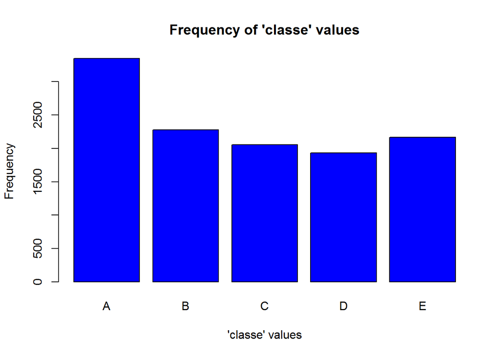

```r
plot(cleanTrainingSet$classe, col="blue",
     main="Frequency of 'classe' values", xlab="'classe' values", ylab="Frequency")
```

As the diagram shows the frequency of values is in a well defined range.

### Training models

For comparison of performance of the models, I build random prediction models offorest, decision tree and gbm methods. Calculating the models takes a long time, so I generate the models once then save the model objects to files, and load the models from the files if they exist.

```r
if(file.exists("gbm.trainingModel.RData")) {
    load(file="gbm.trainingModel.RData", verbose=TRUE)
} else {
    gbm.trainingModel <- train(classe ~ ., data=cleanTrainingSet, method="gbm")
    save(gbm.trainingModel, file="gbm.trainingModel.RData")
}
```

```
## Loading objects:
##   gbm.trainingModel
```

```r
if(file.exists("rf.trainingModel.RData")) {
    load(file="rf.trainingModel.RData", verbose=TRUE)
} else {
    rf.trainingModel <- train(classe ~ ., data=cleanTrainingSet, method="rf")
    save(rf.trainingModel, file="rf.trainingModel.RData")
}
```

```
## Loading objects:
##   rf.trainingModel
```

```r
if(file.exists("rpart.trainingModel.RData")) {
    load(file="rpart.trainingModel.RData", verbose=TRUE)
} else {
    rpart.trainingModel <- rpart(classe ~ ., data=cleanTrainingSet, method="class")
    save(rpart.trainingModel, file="rpart.trainingModel.RData")
}
```

```
## Loading objects:
##   rpart.trainingModel
```

Evaluating the performance of the prediction models

```r
# make the predictions on the validation set
gbm.pred <- predict(gbm.trainingModel, cleanValidationSet)
rf.pred <- predict(rf.trainingModel, cleanValidationSet)
rpart.pred <- predict(rpart.trainingModel, cleanValidationSet, type="class")

# create and print the confusion matrices to compare the predictions
gbm.cfm <- confusionMatrix(gbm.pred, cleanValidationSet$classe)
rf.cfm <- confusionMatrix(rf.pred, cleanValidationSet$classe)
rpart.cfm <- confusionMatrix(rpart.pred, cleanValidationSet$classe)

print("rf:")
```

```
## [1] "rf:"
```

```r
print(rf.cfm$table)
```

```
##           Reference
## Prediction    A    B    C    D    E
##          A 2231    1    0    0    0
##          B    0 1509    5    0    0
##          C    0    8 1363    4    0
##          D    0    0    0 1282    3
##          E    1    0    0    0 1439
```

```r
print(rf.cfm$overall)
```

```
##       Accuracy          Kappa  AccuracyLower  AccuracyUpper   AccuracyNull
##      0.9971960      0.9964534      0.9957578      0.9982420      0.2844762
## AccuracyPValue  McnemarPValue
##      0.0000000            NaN
```

```r
print("gbm:")
```

```
## [1] "gbm:"
```

```r
print(gbm.cfm$table)
```

```
##           Reference
## Prediction    A    B    C    D    E
##          A 2230   17    0    0    0
##          B    2 1475   14    8    5
##          C    0   25 1349   12    4
##          D    0    1    4 1266   14
##          E    0    0    1    0 1419
```

```r
print(gbm.cfm$overall)
```

```
##       Accuracy          Kappa  AccuracyLower  AccuracyUpper   AccuracyNull
##      0.9863625      0.9827471      0.9835439      0.9888106      0.2844762
## AccuracyPValue  McnemarPValue
##      0.0000000            NaN
```

```r
print("rpart:")
```

```
## [1] "rpart:"
```

```r
print(rpart.cfm$table)
```

```
##           Reference
## Prediction    A    B    C    D    E
##          A 2022  263   59   75  107
##          B   90  953  105  113  176
##          C   18   87 1071  199   83
##          D   70  171   77  851  160
##          E   32   44   56   48  916
```

```r
print(rpart.cfm$overall)
```

```
##       Accuracy          Kappa  AccuracyLower  AccuracyUpper   AccuracyNull
##   7.408871e-01   6.708181e-01   7.310401e-01   7.505548e-01   2.844762e-01
## AccuracyPValue  McnemarPValue
##   0.000000e+00   3.894730e-71
```

Very clearly the random forest model is the most accurate (99.72%).

### Expected out of sample error

The expected out of sample error is basically one minus the accuarcy of the validation accuracy:

```r
print(paste("Expected out of sample error:",round(100*(1-0.9972),2),"%"))
```

```
## [1] "Expected out of sample error: 0.28 %"
```

## Prediction

Below is the prediction using the random forest method. The results are also written into a file called “predictionResults.txt”

```r
# predict using the best (random forest) model
test.pred <- predict(rf.trainingModel, testSet)

# print out the result
predResults <- data.frame(testSet$problem_id,test.pred)
print(predResults)
```

```
##    testSet.problem_id test.pred
## 1                   1         B
## 2                   2         A
## 3                   3         B
## 4                   4         A
## 5                   5         A
## 6                   6         E
## 7                   7         D
## 8                   8         B
## 9                   9         A
## 10                 10         A
## 11                 11         B
## 12                 12         C
## 13                 13         B
## 14                 14         A
## 15                 15         E
## 16                 16         E
## 17                 17         A
## 18                 18         B
## 19                 19         B
## 20                 20         B
```

```r
write.table(predResults, file="predictionResults.txt", sep="\t")
```